# AA224 - Advanced Analytics Group Project Assignment 2

30 November 2019

[figure not shown]

# 1. Introduction

The purpose of this project is to create models for the following three techniques:

1. Decision Trees
2. kNN
3. Regression

We begin with a description of the datasets used, and the cleaning that was done to them to make them more usable for the models we created. Next, for each model we explain how the model was created and the performance of those models.

Finally, we present a conclusion of our analyses and the challenges etc. that we faced.

## Packages Required

dplyr  
tidyr  
knitr  
kableExtra

```r
installPackage <- function(name){
  options(repos=c(CRAN="https://ftp.heanet.ie/mirrors/cran.r-project.org/"))
  if(name %in% rownames(installed.packages()) == FALSE) {
    install.packages(name)
  }
}

# function to calc the accuracy of models
calc_accuracy = function(actual, predicted) {
  mean(actual == predicted)
}

installPackage("rpart")
installPackage("rpart.plot")
installPackage("randomForest")
installPackage("gbm")
installPackage("caret")
installPackage("MASS")
installPackage("ISLR")
installPackage("dplyr")
installPackage("tidyr")
installPackage("knitr")
installPackage("kableExtra")
installPackage("data.table")
installPackage("tibble")
installPackage("fastDummies")
installPackage("caret")
installPackage("psych")
install.packages('e1071', dependencies=TRUE)

library(rpart)
library(rpart.plot)
library(randomForest)
library(gbm)
library(caret)
library(MASS)
library(ISLR)
library("dplyr")
library("tidyr")
library("knitr")
library("kableExtra")
library("data.table")
library("tibble")
library("fastDummies")
library("class")
library("caret")
library("psych")
```

# 2. Data Exploration

A description of the datasets with results of the data exploration presented in appropriate tables and plots

### 2.1 Dataset 1 - Decision Trees and kNN classification

```r
str(data_knn)
```

```
## 'data.frame':    285 obs. of  10 variables:
##  $ class      : Factor w/ 2 levels "no-recurrence-events",..: 1 1 1 1 1 1 1 1 1 1 ...
##  $ age        : Factor w/ 6 levels "20-29","30-39",..: 3 3 5 3 5 4 5 3 3 3 ...
##  $ menopause  : Factor w/ 3 levels "ge40","lt40",..: 3 3 1 3 1 3 1 3 3 3 ...
##  $ tumor_size : Factor w/ 11 levels "0-4","10-14",..: 4 4 3 1 3 5 4 11 4 1 ...
##  $ inv_nodes  : Factor w/ 7 levels "0-2","12-14",..: 1 1 1 1 1 1 1 1 1 1 ...
##  $ node_caps  : Factor w/ 3 levels "?","no","yes": 2 2 2 2 2 2 2 2 2 2 ...
##  $ deg_malig  : int  2 2 2 2 2 2 1 2 2 3 ...
##  $ breast     : Factor w/ 2 levels "left","right": 2 1 2 2 1 1 1 1 2 1 ...
##  $ breast_quad: Factor w/ 6 levels "?","central",..: 6 3 4 5 3 3 3 3 4 2 ...
##  $ irradiat   : Factor w/ 2 levels "no","yes": 1 1 1 1 1 1 1 1 1 1 ...
```

Examining the data initially reveals a mixture of nominal and ordinal variables

```r
head(data_knn)
```

```
##                  class   age menopause tumor_size inv_nodes node_caps deg_malig
## 1 no-recurrence-events 40-49   premeno      20-24       0-2        no         2
## 2 no-recurrence-events 40-49   premeno      20-24       0-2        no         2
## 3 no-recurrence-events 60-69      ge40      15-19       0-2        no         2
## 4 no-recurrence-events 40-49   premeno        0-4       0-2        no         2
## 5 no-recurrence-events 60-69      ge40      15-19       0-2        no         2
## 6 no-recurrence-events 50-59   premeno      25-29       0-2        no         2
##   breast breast_quad irradiat
## 1  right    right_up       no
## 2   left    left_low       no
## 3  right     left_up       no
## 4  right   right_low       no
## 5   left    left_low       no
## 6   left    left_low       no
```

```r
summary(data_knn)
```

```
##                   class        age       menopause     tumor_size inv_nodes
##  no-recurrence-events:200   20-29: 1   ge40   :129   30-34  :59   0-2  :212
##  recurrence-events   : 85   30-39:35   lt40   :  7   25-29  :54   12-14:  3
##                             40-49:90   premeno:149   20-24  :50   15-17:  6
##                             50-59:96                 15-19  :30   24-26:  1
##                             60-69:57                 10-14  :28   3-5  : 36
##                             70-79: 6                 40-44  :22   6-8  : 17
##                                                      (Other):42   9-11 : 10
##  node_caps   deg_malig       breast       breast_quad  irradiat
##  ?  :  8   Min.   :1.000   left :151   ?        :  1   no :217
##  no :221   1st Qu.:2.000   right:134   central  : 21   yes: 68
##  yes: 56   Median :2.000               left_low :109
##            Mean   :2.046               left_up  : 97
##            3rd Qu.:3.000               right_low: 24
##            Max.   :3.000               right_up : 33
##
```

Examining the class breakdown percentages shows that the majority of cases have no recurrence events. This disparity is not so significant as to be dangerously weighted to one side, however given the below the baseline for any prediction score should be 70% as the simple assumption of no recurrence would seem to yield that score.

| Var1 | Freq |
| --- | --- |
| no-recurrence-events | 70.2 |
| recurrence-events | 29.8 |

### 2.2 Dataset 2 - Regression

#### 2.2.1 Summary

The dataset ‘Concrete_Data.csv’ describes variables that contribute towards different measurements of concrete compressive strength. According to the dataset source -“The concrete compressive strength is a highly non-linear function of age and ingredients.” It may be fair to assume then that age will have an affect on the compressive strength along with one or more ingredients. These ingredients include cement, blast furnace slag, fly ash, water, superplasticizer, coarse aggregate, and fine aggregate. Concrete compressive strength is the output variable, while the other variables (such as ingredients and age) are input variables.

```r
# Regression: Import data for regression question - concrete compressive strength
df_concrete <- read.csv("data/Concrete_Data.csv")
```

The compressive concrete dataset requires some minor changes to the headers to make them easier to read, namely removing the units.

```r
# Regression: Rename headers (shorten the names)
colnames(df_concrete) <- c("Cement",
                           "Blast Furnace Slag",
                           "Fly Ash",
                           "Water",
                           "Superplasticizer",
                           "Coarse Aggregate",
                           "Fine Aggregate",
                           "Age",
                           "Concrete Comp. Strength")
```

```r
# Regression: Summary of data
summary(df_concrete)
```

```
##      Cement      Blast Furnace Slag    Fly Ash           Water
##  Min.   :102.0   Min.   :  0.0      Min.   :  0.00   Min.   :121.8
##  1st Qu.:192.4   1st Qu.:  0.0      1st Qu.:  0.00   1st Qu.:164.9
##  Median :272.9   Median : 22.0      Median :  0.00   Median :185.0
##  Mean   :281.2   Mean   : 73.9      Mean   : 54.19   Mean   :181.6
##  3rd Qu.:350.0   3rd Qu.:142.9      3rd Qu.:118.30   3rd Qu.:192.0
##  Max.   :540.0   Max.   :359.4      Max.   :200.10   Max.   :247.0
##  Superplasticizer Coarse Aggregate Fine Aggregate       Age
##  Min.   : 0.000   Min.   : 801.0   Min.   :594.0   Min.   :  1.00
##  1st Qu.: 0.000   1st Qu.: 932.0   1st Qu.:731.0   1st Qu.:  7.00
##  Median : 6.400   Median : 968.0   Median :779.5   Median : 28.00
##  Mean   : 6.205   Mean   : 972.9   Mean   :773.6   Mean   : 45.66
##  3rd Qu.:10.200   3rd Qu.:1029.4   3rd Qu.:824.0   3rd Qu.: 56.00
##  Max.   :32.200   Max.   :1145.0   Max.   :992.6   Max.   :365.00
##  Concrete Comp. Strength
##  Min.   : 2.33
##  1st Qu.:23.71
##  Median :34.45
##  Mean   :35.82
##  3rd Qu.:46.13
##  Max.   :82.60
```

#### 2.2.2 Exploring the dependant variable

Creating a histogram of the dependant variable (compressive strength) and by investigating the mean `35.8179612` and median `34.445` (which are similar to each other) we can see that the data appears to be normally distributed.

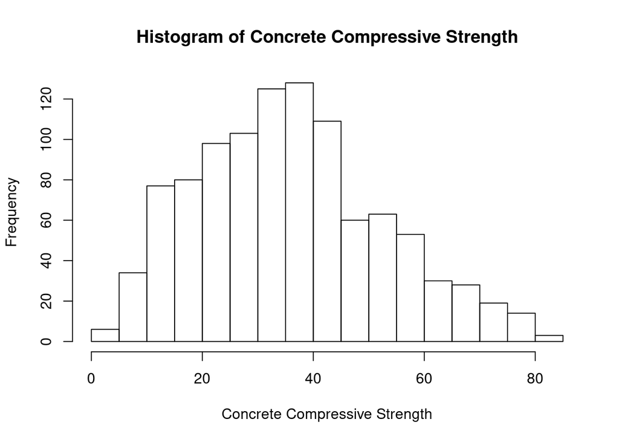

```r
# Investigating the dependant variable
hist(df_concrete$"Concrete Comp. Strength", main='Histogram of Concrete Compressive Strength', xlab='Concrete Compressive Strength')
```

#### 2.2.3 Investigating the relationships between the features

Using the ‘psych’ library we can create a scatterplot matrix to compare the relationships of all the features using pair.panels.

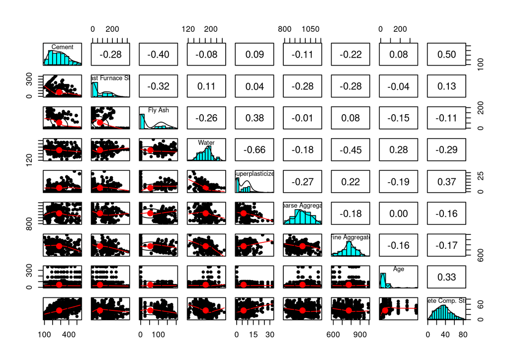

```r
# Creating a scatterplot matrix to investigate the relationships between the features
pairs.panels(df_concrete[c("Cement",
                           "Blast Furnace Slag",
                           "Fly Ash",
                           "Water",
                           "Superplasticizer",
                           "Coarse Aggregate",
                           "Fine Aggregate",
                           "Age",
                           "Concrete Comp. Strength")])
```

The resulting chart above shows that for cement has a stronger relationship than the other features to the concrete compressive strength. We can see this by the increasing sloping line and the higher correlation value between cement and comp. strength. Superplasticizer and age appears to also have a strong relationship with compressive strength. Age is also interesting, in that it appear to increase quite quickly and then level off in terms of its relationship with concrete compressive strength.

#### 2.3 Decision Trees Dataset - Wine Grades

The dataset “wine_data.csv” was taken from https://archive.ics.uci.edu/ml/datasets/Wine.

The data is the result of a chemical analysis of wines grown in the same region in Italy but derived from three different cultivars. These cultivars are treated as the wines class/grade for the purposes of this analysis.

As the data did not come with header names these were added post import. Also the wine “class” was converted from numeric to a factor.

Summary of wine dataframe:

```
##  class     alcohol        malic_acid        ash          alcalinity
##  1:58   Min.   :11.03   Min.   :0.74   Min.   :1.360   Min.   :10.60
##  2:71   1st Qu.:12.36   1st Qu.:1.60   1st Qu.:2.210   1st Qu.:17.20
##  3:48   Median :13.05   Median :1.87   Median :2.360   Median :19.50
##         Mean   :12.99   Mean   :2.34   Mean   :2.366   Mean   :19.52
##         3rd Qu.:13.67   3rd Qu.:3.10   3rd Qu.:2.560   3rd Qu.:21.50
##         Max.   :14.83   Max.   :5.80   Max.   :3.230   Max.   :30.00
##    magnesium         phenols        flavanoids    non_flav_phenols
##  Min.   : 70.00   Min.   :0.980   Min.   :0.340   Min.   :0.1300
##  1st Qu.: 88.00   1st Qu.:1.740   1st Qu.:1.200   1st Qu.:0.2700
##  Median : 98.00   Median :2.350   Median :2.130   Median :0.3400
##  Mean   : 99.59   Mean   :2.292   Mean   :2.023   Mean   :0.3623
##  3rd Qu.:107.00   3rd Qu.:2.800   3rd Qu.:2.860   3rd Qu.:0.4400
##  Max.   :162.00   Max.   :3.880   Max.   :5.080   Max.   :0.6600
##  proanthocyanins     colour            hue            dilute
##  Min.   :0.410   Min.   : 1.280   Min.   :0.480   Min.   :1.270
##  1st Qu.:1.250   1st Qu.: 3.210   1st Qu.:0.780   1st Qu.:1.930
##  Median :1.550   Median : 4.680   Median :0.960   Median :2.780
##  Mean   :1.587   Mean   : 5.055   Mean   :0.957   Mean   :2.604
##  3rd Qu.:1.950   3rd Qu.: 6.200   3rd Qu.:1.120   3rd Qu.:3.170
##  Max.   :3.580   Max.   :13.000   Max.   :1.710   Max.   :4.000
##     proline
##  Min.   : 278.0
##  1st Qu.: 500.0
##  Median : 672.0
##  Mean   : 745.1
##  3rd Qu.: 985.0
##  Max.   :1680.0
```

# Check for N/A’s and blanks

No Need to handle N/A’s or blanks as none were found.

N/A’s:

```
##            class          alcohol       malic_acid              ash
##                0                0                0                0
##       alcalinity        magnesium          phenols       flavanoids
##                0                0                0                0
## non_flav_phenols  proanthocyanins           colour              hue
##                0                0                0                0
##           dilute          proline
##                0                0
```

Blanks:

```
##            class          alcohol       malic_acid              ash
##                0                0                0                0
##       alcalinity        magnesium          phenols       flavanoids
##                0                0                0                0
## non_flav_phenols  proanthocyanins           colour              hue
##                0                0                0                0
##           dilute          proline
##                0                0
```

# 3. kNN

The kNN model was applied to breast cancer data from the UCI machine learning repository, with the class being predicted the recurrence or non-recurrence of breast cancer.

### 3.1 Data Preparation

As can be seen from the structure of the dataset, all of the variables are categorical. They are all factorised with the exception of deg_malig which is now manually facorised:

```r
str(data_knn)
```

```
## 'data.frame':    285 obs. of  10 variables:
##  $ class      : Factor w/ 2 levels "no-recurrence-events",..: 1 1 1 1 1 1 1 1 1 1 ...
##  $ age        : Factor w/ 6 levels "20-29","30-39",..: 3 3 5 3 5 4 5 3 3 3 ...
##  $ menopause  : Factor w/ 3 levels "ge40","lt40",..: 3 3 1 3 1 3 1 3 3 3 ...
##  $ tumor_size : Factor w/ 11 levels "0-4","10-14",..: 4 4 3 1 3 5 4 11 4 1 ...
##  $ inv_nodes  : Factor w/ 7 levels "0-2","12-14",..: 1 1 1 1 1 1 1 1 1 1 ...
##  $ node_caps  : Factor w/ 3 levels "?","no","yes": 2 2 2 2 2 2 2 2 2 2 ...
##  $ deg_malig  : int  2 2 2 2 2 2 1 2 2 3 ...
##  $ breast     : Factor w/ 2 levels "left","right": 2 1 2 2 1 1 1 1 2 1 ...
##  $ breast_quad: Factor w/ 6 levels "?","central",..: 6 3 4 5 3 3 3 3 4 2 ...
##  $ irradiat   : Factor w/ 2 levels "no","yes": 1 1 1 1 1 1 1 1 1 1 ...
```

```r
data_knn$deg_malig = as.factor(data_knn$deg_malig)
```

```r
data_knn_m1 = fastDummies::dummy_cols(data_knn,remove_most_frequent_dummy = T,ignore_na = T )
data_knn_m1 = data_knn_m1[,-c(2:11)]
knitr::kable(head(data_knn_m1)[,1:8]) %>%
    kable_styling(position='left',full_width=F)
```

| class | age_20-29 | age_30-39 | age_40-49 | age_60-69 | age_70-79 | menopause_ge40 | menopause_lt40 |
| --- | --- | --- | --- | --- | --- | --- | --- |
| no-recurrence-events | 0 | 0 | 1 | 0 | 0 | 0 | 0 |
| no-recurrence-events | 0 | 0 | 1 | 0 | 0 | 0 | 0 |
| no-recurrence-events | 0 | 0 | 0 | 1 | 0 | 1 | 0 |
| no-recurrence-events | 0 | 0 | 1 | 0 | 0 | 0 | 0 |
| no-recurrence-events | 0 | 0 | 0 | 1 | 0 | 1 | 0 |
| no-recurrence-events | 0 | 0 | 0 | 0 | 0 | 0 | 0 |

A second approach was to identify possible ordinal variables where the order might provide more information in the model to allow more accurate classification. The possible ordinal variables were defined as age, tumor_size, inv_nodes, deg_malig  
The newly created numeric variables then needed to be normalised to between 0 and 1.

```r
data_knn_nom_vars <- c("menopause","node_caps","breast","breast_quad","irradiat")
data_knn_m2 = fastDummies::dummy_cols(data_knn,remove_most_frequent_dummy = T,ignore_na = T, select_columns = data_knn_nom_vars)
data_knn_ord_vars <- colnames(data_knn)[!(colnames(data_knn) %in% c(data_knn_nom_vars,"class"))]
data_knn_m2$age_n <- as.numeric(data_knn_m2$age)-1
data_knn_m2$tumor_size <- factor(data_knn_m2$tumor_size, levels = c('0-4','5-9','10-14','15-19','20-24','25-29','30-34','35-39','40-44','45-49','50-54'))
data_knn_m2$tumor_size_n <- as.numeric(data_knn_m2$tumor_size)-1
data_knn_m2$inv_nodes <- factor(data_knn_m2$inv_nodes, levels = c("0-2","3-5","6-8","9-11","12-14", "15-17","24-26"))
data_knn_m2$inv_nodes_n <- as.numeric(data_knn_m2$inv_nodes)-1
data_knn_m2$deg_malig_n <- as.numeric(data_knn_m2$deg_malig) - 1

normfn <- function(inlist) {
  inlist = inlist/max(inlist)
  return(inlist)
}
data_knn_m2[,names(data_knn_m2) %in% paste0(data_knn_ord_vars,"_n")] <- lapply(data_knn_m2[,names(data_knn_m2) %in% paste0(data_knn_ord_vars,"_n")], normfn)
data_knn_m2 = data_knn_m2[,-c(2:10)]
knitr::kable(head(data_knn_m2)[,c(1,13:16)]) %>%
    kable_styling(position='left',full_width=F)
```

| class | age_n | tumor_size_n | inv_nodes_n | deg_malig_n |
| --- | --- | --- | --- | --- |
| no-recurrence-events | 0.4 | 0.4 | 0 | 0.5 |
| no-recurrence-events | 0.4 | 0.4 | 0 | 0.5 |
| no-recurrence-events | 0.8 | 0.3 | 0 | 0.5 |
| no-recurrence-events | 0.4 | 0.0 | 0 | 0.5 |
| no-recurrence-events | 0.8 | 0.3 | 0 | 0.5 |
| no-recurrence-events | 0.6 | 0.5 | 0 | 0.5 |

### 3.2 Predictive Model

Building the kNN model does not require many steps, as it is a very simple lazy learning algorithm.  
Data was split into training and test as a first step, using a 70:30 split for Train:Test. The same split was used for both models 1 and 2

```r
set.seed(12)
train <-sample(nrow(data_knn), 0.7*nrow(data_knn), replace = FALSE)
```

The data was then split for model 1 and model 2 using the same split. The class labels for each were also stored

```r
#training and test sets
train_knn_m1 <-data_knn_m1[train,-1]
test_knn_m1 <-data_knn_m1[-train,-1]
#training and test class labels
train_knn_class_m1 <- data_knn_m1[train,1]
test_knn_class_m1 <- data_knn_m1[-train,1]

#training and test sets
train_knn_m2 <-data_knn_m2[train,-1]
test_knn_m2 <-data_knn_m2[-train,-1]
#training and test class labels
train_knn_class_m2 <- data_knn_m2[train,1]
test_knn_class_m2 <- data_knn_m2[-train,1]
```

An initial run of each model was constructed using an arbitrary k=5 value

```r
knn_pred_m1 <- knn(train_knn_m1,test_knn_m1, cl=train_knn_class_m1, k=5)
knn_pred_m2 <- knn(train_knn_m2,test_knn_m2, cl=train_knn_class_m2, k=5)
summary(knn_pred_m1)
```

```
## no-recurrence-events    recurrence-events
##                   73                   13
```

```r
summary(knn_pred_m2)
```

```
## no-recurrence-events    recurrence-events
##                   66                   20
```

### 3.3 Evaluation of model Performance

In order to optimise the models and compare performance, it was necessary to test different values of k. For each model, the kNN algorithm was run multiple times to create a picture of the solution space

```r
m1_results = data.frame(k=c(0,0),Accuracy=c(0,0), Acc_pvalue = c(0,0))
m1_models <- list()
for (k in c(1:50)) {
  knn_pred_m1 <- knn(train_knn_m1,test_knn_m1, cl=train_knn_class_m1, k=k)
  cm_m1 <- confusionMatrix(knn_pred_m1, test_knn_class_m1)
  m1_results[k,] = c(k,cm_m1$overall[1],cm_m1$overall[6])
  m1_models[[k]] = knn_pred_m1
}
knitr::kable(m1_results[1:15,]) %>%
    kable_styling(position='left',full_width=F)
```

| k | Accuracy | Acc_pvalue |
| --- | --- | --- |
| 1 | 0.6860465 | 0.8013978 |
| 2 | 0.7674419 | 0.2015491 |
| 3 | 0.7790698 | 0.1388138 |
| 4 | 0.7441860 | 0.3651626 |
| 5 | 0.7325581 | 0.4591865 |
| 6 | 0.7441860 | 0.3651626 |
| 7 | 0.7325581 | 0.4591865 |
| 8 | 0.7441860 | 0.3651626 |
| 9 | 0.7325581 | 0.4591865 |
| 10 | 0.7325581 | 0.4591865 |
| 11 | 0.7325581 | 0.4591865 |
| 12 | 0.7441860 | 0.3651626 |
| 13 | 0.7441860 | 0.3651626 |
| 14 | 0.7325581 | 0.4591865 |
| 15 | 0.7325581 | 0.4591865 |

To try to assess the best performing value of k, the accuracy and also the p-value as provided by the Confusion Matrix function from the caret package were used. Graphically this can be seen below.

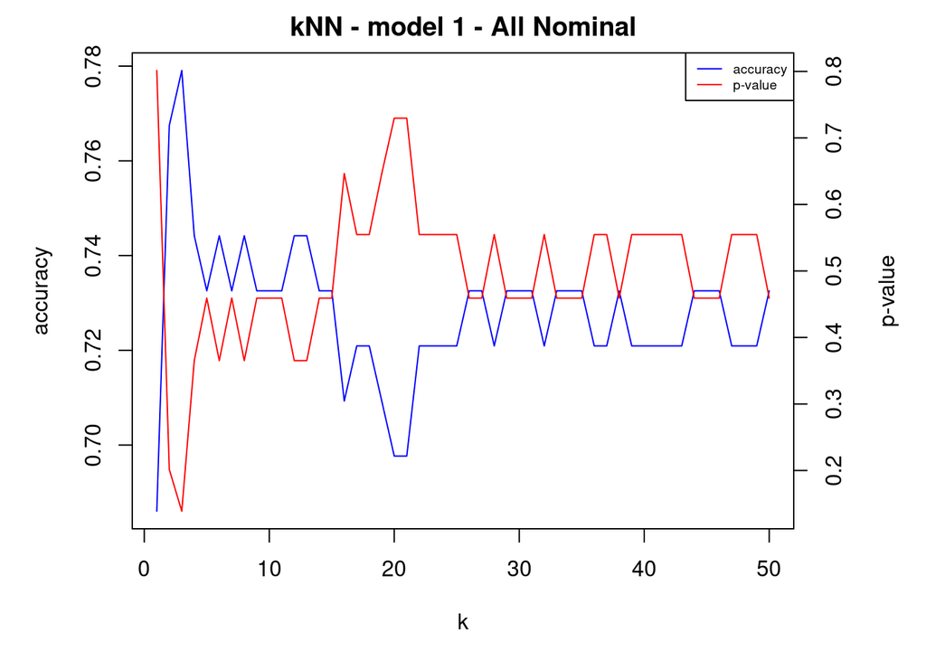

```r
par(mar = c(5,5,2,5))
plot(m1_results$k,m1_results$Accuracy, type="l", xlab="k", ylab="accuracy", col="blue",main ="kNN - model 1 - All Nominal")

par(new = T)
plot(m1_results$k,m1_results$Acc_pvalue, type="l", axes=F, xlab=NA, ylab=NA, col="red")
axis(side = 4)
mtext(side = 4, line = 3, 'p-value')
legend("topright", legend = c("accuracy", "p-value"), col=c("blue","red"), cex=0.6, lty = 1)
```

```r
m2_results = data.frame(k=c(0,0),Accuracy=c(0,0), Acc_pvalue = c(0,0))
m2_models <- list()
for (k in c(1:50)) {
  knn_pred_m2 <- knn(train_knn_m2,test_knn_m2, cl=train_knn_class_m2, k=k)
  cm_m2 <- confusionMatrix(knn_pred_m2, test_knn_class_m2)
  m2_results[k,] = c(k,cm_m2$overall[1],cm_m2$overall[6])
  m2_models[[k]] = knn_pred_m2
}
knitr::kable(m2_results[1:15,]) %>%
    kable_styling(position='left',full_width=F)
```

| k | Accuracy | Acc_pvalue |
| --- | --- | --- |
| 1 | 0.6279070 | 0.9771264 |
| 2 | 0.6511628 | 0.9383719 |
| 3 | 0.6627907 | 0.9050923 |
| 4 | 0.6744186 | 0.8598438 |
| 5 | 0.6860465 | 0.8013978 |
| 6 | 0.7209302 | 0.5547269 |
| 7 | 0.7441860 | 0.3651626 |
| 8 | 0.7325581 | 0.4591865 |
| 9 | 0.7558140 | 0.2778722 |
| 10 | 0.7441860 | 0.3651626 |
| 11 | 0.7441860 | 0.3651626 |
| 12 | 0.7790698 | 0.1388138 |
| 13 | 0.7093023 | 0.6464457 |
| 14 | 0.7209302 | 0.5547269 |
| 15 | 0.7558140 | 0.2778722 |

The performance when allowing ordinal values appears to be better as can be seen below

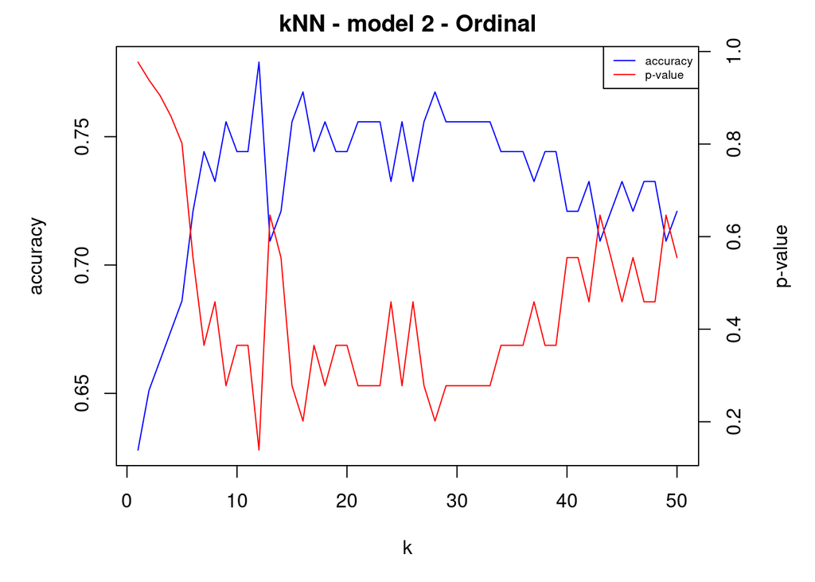

```r
par(mar = c(5,5,2,5))
plot(m2_results$k,m2_results$Accuracy, type="l", xlab="k", ylab="accuracy", col="blue",main ="kNN - model 2 - Ordinal")

par(new = T)
plot(m2_results$k,m2_results$Acc_pvalue, type="l", axes=F, xlab=NA, ylab=NA, col="red")
axis(side = 4)
mtext(side = 4, line = 3, 'p-value')
legend("topright", legend = c("accuracy", "p-value"), col=c("blue","red"), cex=0.6, lty = 1)
```

# 4. Regression

As mentioned previously, the concrete compressive strength in the dataset is the dependant variable, and we are trying to use the features to model this output variable. We will creat a model using all the features(as it is hypotheized that they are all important) and then use techniques such as stepwise selection to see what can be changed in the model to make it more effective. Finally, an anlyisis will be done on the summary of the final model to asses performance.

### 4.1 Data Preparation

As the data was already clean, no further work was required (other than the renaming of variables previously done).

### 4.2 Predictive Model

The intial pass at the model used all the features.

```r
# create a model on the concrete data using all features
concrete_model <- lm(df_concrete$"Concrete Comp. Strength" ~ Cement + `Blast Furnace Slag` +
                        `Fly Ash` + Water + Superplasticizer + `Coarse Aggregate` +
                        `Fine Aggregate` + Age, data = df_concrete)
```

In order to confirm if a subset of the features could be used to develop the model, we used stepwise selection to confirm if any features could be left out (or which features would perform the best)

```r
# Use stepwise regression to check if any variables can be possibly removed from the model
step(concrete_model)
```

```
## Start:  AIC=4832.91
## df_concrete$"Concrete Comp. Strength" ~ Cement + `Blast Furnace Slag` +
##     `Fly Ash` + Water + Superplasticizer + `Coarse Aggregate` +
##     `Fine Aggregate` + Age
##
##                        Df Sum of Sq    RSS    AIC
## <none>                              110413 4832.9
## - `Fine Aggregate`      1       385 110798 4834.5
## - `Coarse Aggregate`    1       401 110814 4834.6
## - Superplasticizer      1      1058 111471 4840.7
## - Water                 1      1506 111919 4844.9
## - `Fly Ash`             1      5281 115694 4879.0
## - `Blast Furnace Slag`  1     11356 121769 4931.7
## - Cement                1     21539 131952 5014.5
## - Age                   1     47902 158315 5202.1
```

```
##
## Call:
## lm(formula = df_concrete$"Concrete Comp. Strength" ~ Cement +
##     `Blast Furnace Slag` + `Fly Ash` + Water + Superplasticizer +
##     `Coarse Aggregate` + `Fine Aggregate` + Age, data = df_concrete)
##
## Coefficients:
##          (Intercept)                Cement  `Blast Furnace Slag`
##            -23.33121               0.11980               0.10387
##            `Fly Ash`                 Water      Superplasticizer
##              0.08793              -0.14992               0.29222
##   `Coarse Aggregate`      `Fine Aggregate`                   Age
##              0.01809               0.02019               0.11422
```

From the above, it appears that all the features contribute somewhat significantly - and I believe this to be due to the fact that all these constitute parts to indeed improve compressive strength in concrete. However, in what quantities would be a different question.

A second model was created with an interaction feature added in (cement and age). These were combined as it appeared from the summary results of the model and the investigation into the relationship between the features that these were influential on the strength of the concrete.

```r
# Adding interaction term to generate new model (testing for interaction between cement and age)
concrete_model_CA <- lm(df_concrete$"Concrete Comp. Strength" ~ Cement + `Blast Furnace Slag` +
                       `Fly Ash` + Water + Superplasticizer + `Coarse Aggregate` +
                       `Fine Aggregate` + Age + Cement*Age, data = df_concrete)
```

### 4.3 Evaluation of model Performance

The summary command shows us the performance of our first model (all the features used).

```r
# Evaluate model performance using all the features
summary(concrete_model)
```

```
##
## Call:
## lm(formula = df_concrete$"Concrete Comp. Strength" ~ Cement +
##     `Blast Furnace Slag` + `Fly Ash` + Water + Superplasticizer +
##     `Coarse Aggregate` + `Fine Aggregate` + Age, data = df_concrete)
##
## Residuals:
##     Min      1Q  Median      3Q     Max
## -28.654  -6.302   0.703   6.569  34.450
##
## Coefficients:
##                        Estimate Std. Error t value Pr(>|t|)
## (Intercept)          -23.331214  26.585504  -0.878 0.380372
## Cement                 0.119804   0.008489  14.113  < 2e-16 ***
## `Blast Furnace Slag`   0.103866   0.010136  10.247  < 2e-16 ***
## `Fly Ash`              0.087934   0.012583   6.988 5.02e-12 ***
## Water                 -0.149918   0.040177  -3.731 0.000201 ***
## Superplasticizer       0.292225   0.093424   3.128 0.001810 **
## `Coarse Aggregate`     0.018086   0.009392   1.926 0.054425 .
## `Fine Aggregate`       0.020190   0.010702   1.887 0.059491 .
## Age                    0.114222   0.005427  21.046  < 2e-16 ***
## ---
## Signif. codes:  0 '***' 0.001 '**' 0.01 '*' 0.05 '.' 0.1 ' ' 1
##
## Residual standard error: 10.4 on 1021 degrees of freedom
## Multiple R-squared:  0.6155, Adjusted R-squared:  0.6125
## F-statistic: 204.3 on 8 and 1021 DF,  p-value: < 2.2e-16
```

From the residuals we can see that the errors are quite small, with the predictive values being 6 MPa over/under the true value. We have several features that contribute significantly to the model, in particular we can see cement, blast furnace slag and age being particular powerful and highly statistically significant.

We added an interaction feature in our second model, and the results were as follows:

```r
# Evaluate model performance with new feature added
summary(concrete_model_CA)
```

```
##
## Call:
## lm(formula = df_concrete$"Concrete Comp. Strength" ~ Cement +
##     `Blast Furnace Slag` + `Fly Ash` + Water + Superplasticizer +
##     `Coarse Aggregate` + `Fine Aggregate` + Age + Cement * Age,
##     data = df_concrete)
##
## Residuals:
##     Min      1Q  Median      3Q     Max
## -33.130  -6.185   0.746   6.677  34.438
##
## Coefficients:
##                        Estimate Std. Error t value Pr(>|t|)
## (Intercept)          -2.005e+01  2.640e+01  -0.760 0.447723
## Cement                1.269e-01  8.613e-03  14.738  < 2e-16 ***
## `Blast Furnace Slag`  1.009e-01  1.009e-02   9.998  < 2e-16 ***
## `Fly Ash`             8.537e-02  1.251e-02   6.825 1.51e-11 ***
## Water                -1.530e-01  3.989e-02  -3.835 0.000133 ***
## Superplasticizer      2.966e-01  9.275e-02   3.197 0.001430 **
## `Coarse Aggregate`    1.673e-02  9.330e-03   1.793 0.073319 .
## `Fine Aggregate`      1.601e-02  1.067e-02   1.499 0.134079
## Age                   1.804e-01  1.737e-02  10.388  < 2e-16 ***
## Cement:Age           -2.132e-04  5.320e-05  -4.008 6.57e-05 ***
## ---
## Signif. codes:  0 '***' 0.001 '**' 0.01 '*' 0.05 '.' 0.1 ' ' 1
##
## Residual standard error: 10.32 on 1020 degrees of freedom
## Multiple R-squared:  0.6215, Adjusted R-squared:  0.6181
## F-statistic: 186.1 on 9 and 1020 DF,  p-value: < 2.2e-16
```

Reviewing the plots of our final model, it appears that the data is not affected by outliers and that the data comes from a normal distribution (as seen in the QQ plot).

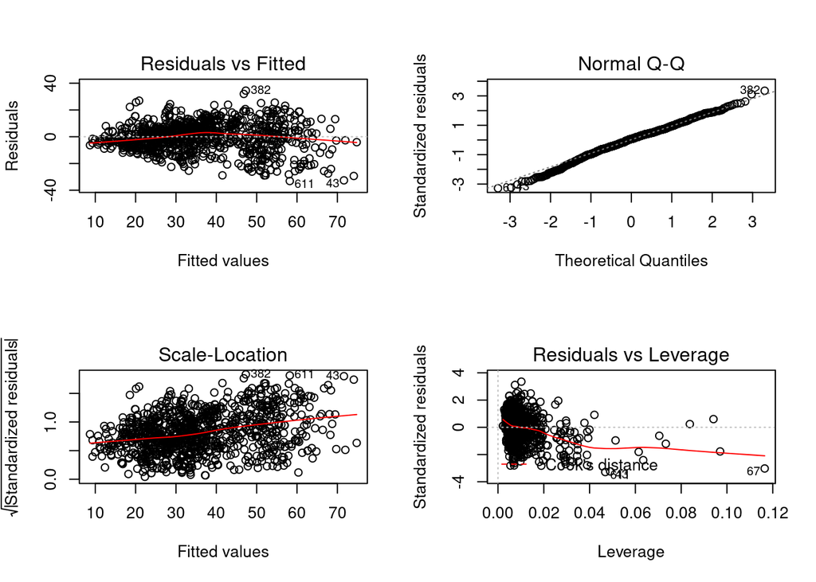

```r
# Plots of model generated
par(mfrow=c(2,2))
plot(concrete_model_CA)
```

# 5. Decision Tree

### Split to train and test

We’re ready to split our data into train and test data sets.

```r
# Split into training and test at 70/30 ratio
set.seed(100)
train <- sample(nrow(wine_df), 0.7*nrow(wine_df), replace = FALSE)
wine_trn <- wine_df[train,]
wine_tst <- wine_df[-train,]
```

Training summary:

```
##  class     alcohol        malic_acid         ash          alcalinity
##  1:42   Min.   :11.03   Min.   :0.900   Min.   :1.700   Min.   :12.40
##  2:45   1st Qu.:12.37   1st Qu.:1.645   1st Qu.:2.205   1st Qu.:17.35
##  3:36   Median :13.05   Median :1.950   Median :2.360   Median :19.50
##         Mean   :13.01   Mean   :2.427   Mean   :2.385   Mean   :19.69
##         3rd Qu.:13.63   3rd Qu.:3.205   3rd Qu.:2.595   3rd Qu.:21.50
##         Max.   :14.83   Max.   :5.800   Max.   :3.230   Max.   :30.00
##    magnesium        phenols        flavanoids    non_flav_phenols
##  Min.   : 78.0   Min.   :0.980   Min.   :0.340   Min.   :0.1300
##  1st Qu.: 89.0   1st Qu.:1.795   1st Qu.:1.055   1st Qu.:0.2600
##  Median : 98.0   Median :2.420   Median :2.170   Median :0.3200
##  Mean   :100.3   Mean   :2.317   Mean   :2.042   Mean   :0.3571
##  3rd Qu.:106.5   3rd Qu.:2.800   3rd Qu.:2.905   3rd Qu.:0.4600
##  Max.   :162.0   Max.   :3.850   Max.   :5.080   Max.   :0.6600
##  proanthocyanins     colour            hue             dilute
##  Min.   :0.410   Min.   : 1.900   Min.   :0.4800   Min.   :1.290
##  1st Qu.:1.200   1st Qu.: 3.400   1st Qu.:0.7750   1st Qu.:1.945
##  Median :1.540   Median : 5.000   Median :0.9500   Median :2.780
##  Mean   :1.591   Mean   : 5.181   Mean   :0.9481   Mean   :2.608
##  3rd Qu.:1.955   3rd Qu.: 6.225   3rd Qu.:1.1200   3rd Qu.:3.190
##  Max.   :3.580   Max.   :13.000   Max.   :1.7100   Max.   :3.820
##     proline
##  Min.   : 278.0
##  1st Qu.: 510.0
##  Median : 680.0
##  Mean   : 755.8
##  3rd Qu.: 987.5
##  Max.   :1680.0
```

Test summary:

```
##  class     alcohol        malic_acid         ash          alcalinity
##  1:16   Min.   :11.41   Min.   :0.740   Min.   :1.360   Min.   :10.60
##  2:26   1st Qu.:12.23   1st Qu.:1.515   1st Qu.:2.215   1st Qu.:16.88
##  3:12   Median :12.84   Median :1.765   Median :2.320   Median :19.20
##         Mean   :12.96   Mean   :2.141   Mean   :2.324   Mean   :19.13
##         3rd Qu.:13.76   3rd Qu.:2.490   3rd Qu.:2.495   3rd Qu.:21.50
##         Max.   :14.75   Max.   :4.720   Max.   :2.840   Max.   :28.50
##    magnesium         phenols        flavanoids    non_flav_phenols
##  Min.   : 70.00   Min.   :1.150   Min.   :0.470   Min.   :0.1400
##  1st Qu.: 88.00   1st Qu.:1.700   1st Qu.:1.290   1st Qu.:0.2725
##  Median : 95.50   Median :2.200   Median :2.025   Median :0.3900
##  Mean   : 98.02   Mean   :2.237   Mean   :1.981   Mean   :0.3743
##  3rd Qu.:108.00   3rd Qu.:2.650   3rd Qu.:2.740   3rd Qu.:0.4300
##  Max.   :151.00   Max.   :3.880   Max.   :3.740   Max.   :0.6100
##  proanthocyanins     colour            hue             dilute
##  Min.   :0.420   Min.   : 1.280   Min.   :0.5400   Min.   :1.270
##  1st Qu.:1.285   1st Qu.: 2.737   1st Qu.:0.8025   1st Qu.:1.897
##  Median :1.565   Median : 4.150   Median :1.0300   Median :2.780
##  Mean   :1.577   Mean   : 4.768   Mean   :0.9772   Mean   :2.597
##  3rd Qu.:1.870   3rd Qu.: 5.737   3rd Qu.:1.1200   3rd Qu.:3.095
##  Max.   :2.960   Max.   :11.750   Max.   :1.4200   Max.   :4.000
##     proline
##  Min.   : 312.0
##  1st Qu.: 495.0
##  Median : 627.5
##  Mean   : 720.6
##  3rd Qu.: 906.2
##  Max.   :1547.0
```

### Tree Model

Our first model will be a single decision tree. Here we create the tree, train on our training set and plot it:

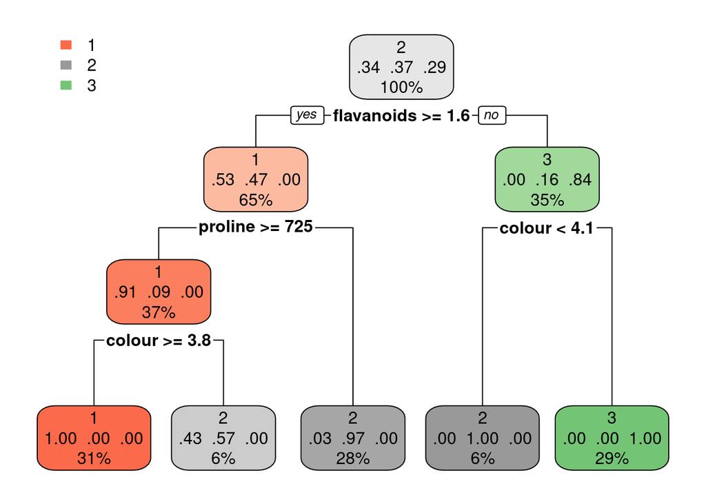

```r
# Create the model
wine_tree = rpart(class ~ ., data = wine_trn)
# Plot the tree
rpart.plot(wine_tree)
```

We then predict on our test set and output an actual vs predicted table:

```r
# Predict on test set
wine_tree_tst_pred = predict(wine_tree, wine_tst, type = "class")
# Predicted vs Actual
table(predicted = wine_tree_tst_pred, actual = wine_tst$class)
```

```
##          actual
## predicted  1  2  3
##         1 16  0  0
##         2  0 25  2
##         3  0  1 10
```

The accuracy of the model is:

```
## [1] 0.9444444
```

### Bagging Model

Our next model is bagging. Similar to before we create the tree, train on our training set but this time output the error rate and confusion matrix.

The reason for this is that bagging produces many trees and it would be pointless to plot just one of them.

```r
# Create the model
wine_bag = randomForest(class ~ ., data = wine_trn, mtry = 10,
                        importance = TRUE, ntrees = 500)

# Error rate and confusion matrix
wine_bag
```

```
##
## Call:
##  randomForest(formula = class ~ ., data = wine_trn, mtry = 10,      importance = TRUE, ntrees = 500)
##                Type of random forest: classification
##                      Number of trees: 500
## No. of variables tried at each split: 10
##
##         OOB estimate of  error rate: 2.44%
## Confusion matrix:
##    1  2  3 class.error
## 1 41  1  0  0.02380952
## 2  1 44  0  0.02222222
## 3  1  0 35  0.02777778
```

We can plot the error rate by number of trees created:

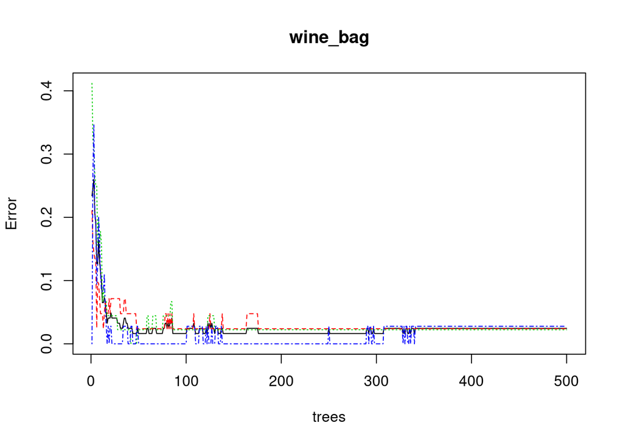

We then predict on our test set and output an actual vs predicted table:

```r
# Predict on test set
wine_bag_tst_pred = predict(wine_bag, newdata = wine_tst)
# Predicted vs Actual
table(predicted = wine_bag_tst_pred, actual = wine_tst$class)
```

```
##          actual
## predicted  1  2  3
##         1 16  0  0
##         2  0 24  0
##         3  0  2 12
```

The models accuracy is:

```
## [1] 0.962963
```

### Random Forest Model

Our final model is Random Forest.

Again, we create, train and output the the error rate and confusion matrix.

```r
# Create the model
wine_forest = randomForest(class ~ ., data = wine_trn, mtry = 3,
                           importance = TRUE, ntrees = 500)

# Error rate and confusion matrix
wine_forest
```

```
##
## Call:
##  randomForest(formula = class ~ ., data = wine_trn, mtry = 3,      importance = TRUE, ntrees = 500)
##                Type of random forest: classification
##                      Number of trees: 500
## No. of variables tried at each split: 3
##
##         OOB estimate of  error rate: 1.63%
## Confusion matrix:
##    1  2  3 class.error
## 1 42  0  0  0.00000000
## 2  1 43  1  0.04444444
## 3  0  0 36  0.00000000
```

Plot the error rate by number of trees created:

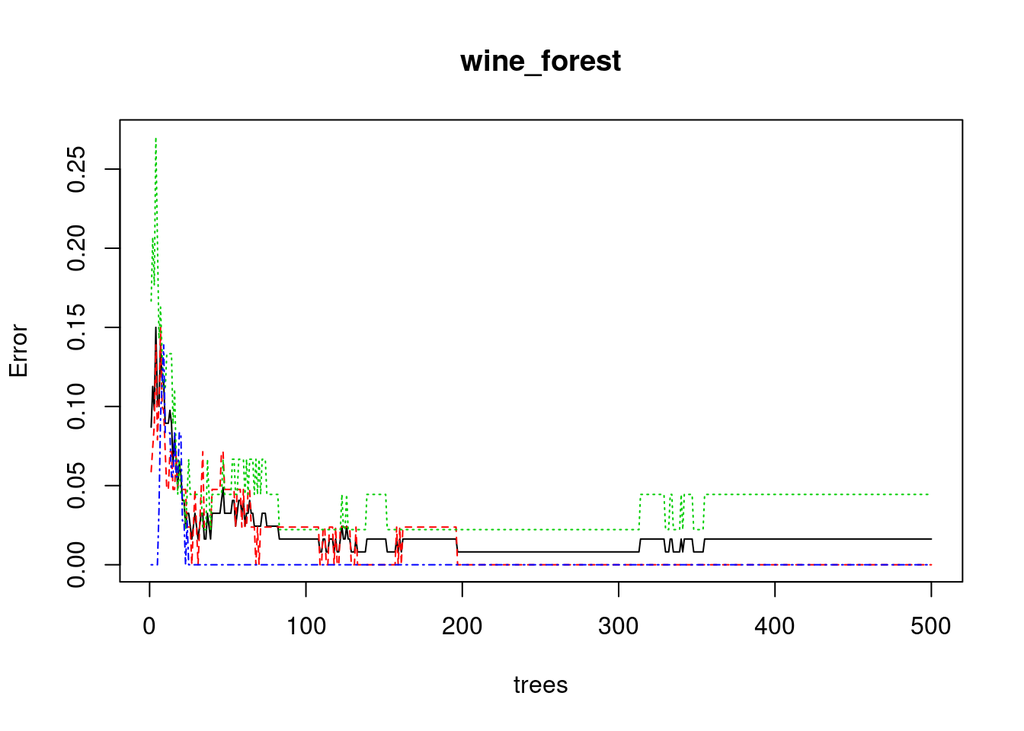

Predict on our test set and output an actual vs predicted table:

```r
# Predict on test set
wine_forest_tst_perd = predict(wine_forest, newdata = wine_tst)
# Predicted vs Actual
table(predicted = wine_forest_tst_perd, actual = wine_tst$class)
```

```
##          actual
## predicted  1  2  3
##         1 16  0  0
##         2  0 24  0
##         3  0  2 12
```

Random Forests accuracy:

```
## [1] 0.962963
```

### Comparison

To compare the three models a dataframe is made up from their accuracy outputs and printed.

```
##           Model TestAccuracy
## 1   Single Tree    0.9444444
## 2       Bagging    0.9629630
## 3 Random Forest    0.9629630
```

### Fine Tuning

We can fine tune each of these models if we choose to. As an example I have tuned the Random forest model.

As a default the mtry is set to 3. The block of code below will try every possible mtry value and log the accuracy of each.

```r
# Set the train control method
oob = trainControl(method = "oob")

# Build grid of mtry needed to find most accurate number of predictors used
rf_grid =  expand.grid(mtry = 1:13)

# Tune RF using oob and fr_grid
set.seed(1000)
wine_rf_tune = train(class~ ., data = wine_trn,
                     method = "rf",
                     trControl = oob,
                     verbose = FALSE,
                     tuneGrid = rf_grid)
```

We can then view this log and see the optimal value for mtry.

```
## Random Forest
##
## 123 samples
##  13 predictor
##   3 classes: '1', '2', '3'
##
## No pre-processing
## Resampling results across tuning parameters:
##
##   mtry  Accuracy   Kappa
##    1    0.9918699  0.9877575
##    2    0.9837398  0.9755370
##    3    0.9918699  0.9877575
##    4    0.9837398  0.9755078
##    5    0.9837398  0.9755078
##    6    0.9756098  0.9632945
##    7    0.9837398  0.9755078
##    8    0.9837398  0.9755078
##    9    0.9837398  0.9755078
##   10    0.9837398  0.9755078
##   11    0.9837398  0.9755078
##   12    0.9837398  0.9755078
##   13    0.9837398  0.9755078
##
## Accuracy was used to select the optimal model using the largest value.
## The final value used for the model was mtry = 1.
```

A plot of accuracy by mtry value used:

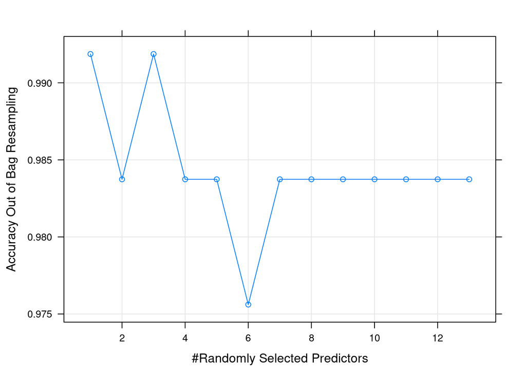

The best accuracy achieved:

```
## [1] 0.9814815
```

This is achieved by using an mtry value of:

```
##   mtry
## 1    1
```

### Tuned Random Forest

```r
wine_forest_tuned = randomForest(class ~ ., data = wine_trn, mtry = 2,
                                 importance = TRUE, ntrees = 500)

tuned_wine_forest_tst_perd = predict(wine_forest_tuned, newdata = wine_tst)
table(predicted = tuned_wine_forest_tst_perd, actual = wine_tst$class)
```

```
##          actual
## predicted  1  2  3
##         1 16  0  0
##         2  0 24  0
##         3  0  2 12
```

```
## [1] 0.962963
```

### Compare all

Finally, the tuned model is added to the comparrison table:

```
##                 Model TestAccuracy
## 1         Single Tree    0.9444444
## 2             Bagging    0.9629630
## 3       Random Forest    0.9629630
## 4 Random Forest Tuned    0.9629630
```

# 6. Discussion/Reflection

The work was split up amongst the team where individually we would work on creating the models and then once complete, review the work done and merge the script changes in github. Gavin Byrne carried out the decision tree analysis, Brendan Lynch the kNN analysis and Luke Feeney the regression analysis. Finally we worked together to create the final markdown file.

For the kNN models, the dataset used was challenging in terms of being completely categorical and thus requiring a lot of preprocessing. The decision whether to treat certain variables as nominal or ordinal appears to have allowed some improvement in model performance. However overall, the kNN method did not seem to be most suited for predictive accuracy and in a fuller analysis, comparison with other classifiers would have been carried out.

For the regression problem, the dataset was interesting in terms of some of the background research into concrete compressive strength. As the data required little to no cleaning, not much can be said about the state of the data other than that it was very easy to work with. Creating the model brought up some interesting results, namely that while cement would clearly be a large factor in creating concrete, that age plays a significant part in improving compressive strength. Adding in age and cement as an interaction feature, did not have as strong as an effect as it seemingly would have. It did improve the adjusted R squared value, but we were expecting that it would have had a better effect on the performance of the model.

Having been assigned Decision Trees I was unsure whether analysis using a single tree would meet the brief. Due to this concern I chose to analyse my dataset using three models and then compare & contrast.

From running a single tree, a bagged RF and a random forest I have learned about the strenghts and weaknesses of each. One important lesson however was to ensure your chosen model fits the dataset you are working with. I’m relatively certain my wine dataset is not a good match for classification by decision trees.